# Exploratory Data Analysis

In an attempt to gather additional information regarding the playlist and their inner consistency an exploratory analysis is being performed.

First a general overview of all basic features is delivered. Second additional features [such as artist and track popularity] are being computed to offer a holistic view on the characteristics of this playlist aggregation.

```python
import datetime
import html
import json
import matplotlib.pyplot as plt
import nltk
import numpy as np
import os
import pandas as pd
import pickle
import random
import re
import seaborn as sns

from collections import Counter
from IPython.display import clear_output
from scipy import stats

random.seed(2018)

%matplotlib inline
```

## Overview

Before diving into the data, here are some pointers from Spotify's official readme file regarding the features:

### Data Set

Each slice file is a JSON dictionary with two fields: *info* and *playlists*.

#### `info` Field

The info field is a dictionary that contains general information about the particular slice:

- **slice** - the range of slices that in in this particular file - such as 0-999
- *version* - - the current version of the MPD (which should be v1)
- *generated_on* - a timestamp indicating when the slice was generated.

#### `playlists` field

This is an array that typically contains 1,000 playlists.

#### Playlist JSON

Each playlist is a dictionary that contains the following fields:

- *pid* - integer - playlist id - the MPD ID of this playlist. This is an integer between 0 and 999,999.
- *name* - string - the name of the playlist
- *description* - optional string - if present, the description given to the playlist. Note that user-provided playlist descrptions are a relatively new feature of Spotify, so most playlists do not have descriptions.
- *modified_at* - seconds - timestamp (in seconds since the epoch) when this playlist was last updated. Times are rounded to midnight GMT of the date when the playlist was last updated.
- *num_artists* - the total number of unique artists for the tracks in the playlist.
- *num_albums* - the number of unique albums for the tracks in the playlist
- *num_tracks* - the number of tracks in the playlist
- *num_followers* - the number of followers this playlist had at the time the MPD was created. (Note that the follower count does not including the playlist creator)
- *num_edits* - the number of separate editing sessions. Tracks added in a two hour window are considered to be added in a single editing session.
- *duration_ms* - the total duration of all the tracks in the playlist (in milliseconds)
- *collaborative* - boolean - if true, the playlist is a collaborative playlist. Multiple users may contribute tracks to a collaborative playlist.
- *tracks* - an array of information about each track in the playlist. Each element in the array is a dictionary with the following fields:
  - *track_name* - the name of the track
  - *track_uri* - the Spotify URI of the track
  - *album_name* - the name of the track's album
  - *album_uri* - the Spotify URI of the album
  - *artist_name* - the name of the track's primary artist
  - *artist_uri* - the Spotify URI of track's primary artist
  - *duration_ms* - the duration of the track in milliseconds
  - *pos* - the position of the track in the playlist (zero-based)

## How was the dataset built

The Million Playist Dataset is created by sampling playlists from the billions of playlists that Spotify users have created over the years. Playlists that meet the following criteria are selected at random:

- Created by a user that resides in the United States and is at least 13 years old
- Was a public playlist at the time the MPD was generated
- Contains at least 5 tracks
- Contains no more than 250 tracks
- Contains at least 3 unique artists
- Contains at least 2 unique albums
- Has no local tracks (local tracks are non-Spotify tracks that a user has on their local device)
- Has at least one follower (not including the creator)
- Was created after January 1, 2010 and before December 1, 2017
- Does not have an offensive title
- Does not have an adult-oriented title if the playlist was created by a user under 18 years of age

Additionally, some playlists have been modified as follows:

- Potentially offensive playlist descriptions are removed
- Tracks added on or after November 1, 2017 are removed

```python
# setup and housekeeping
PLAYLIST_FOLDER = '../data'
RESULTS_FOLDER = 'results/'
example_file = 'mpd.slice.5000-5999.json'
recompute = True  # recomputation flag
```

```python
# create results folder
if not os.path.exists(RESULTS_FOLDER):
    os.makedirs(RESULTS_FOLDER)
```

```python
def open_json(file_name):
    """
    Helper method to open and return json
    file.

    Parameters:
    --------------
    file_name: string representation of path to json file

    Returns:
    --------------
    tmp_playlist_json: json object
    """
    with open(file_name, 'r') as f:
        tmp_playlist_json = json.load(f)
    return tmp_playlist_json
```

```python
def write_dict(dic, file_name):
    with open(file_name, 'wb') as f:
        pickle.dump(dic, f)
        print ('Stored file under {}'.format(file_name))
```

```python
def open_dict(file_name):
    with open(file_name, 'rb') as f:
        tmp_dict = pickle.load(f)
    return tmp_dict
```

```python
test_playlist_file = open_json(os.path.join(PLAYLIST_FOLDER, example_file))
```

```python
test_playlist_file['info']
```

```
{'generated_on': '2017-12-03 08:41:42.057563',
 'slice': '5000-5999',
 'version': 'v1'}
```

```python
test_playlist_file['playlists'][0]['tracks'][:3]  # first 3 tracks of first playlist
```

```
[{'album_name': 'Blood Bank',
  'album_uri': 'spotify:album:04MsTCBM8AneW8jxZVHKcA',
  'artist_name': 'Bon Iver',
  'artist_uri': 'spotify:artist:4LEiUm1SRbFMgfqnQTwUbQ',
  'duration_ms': 157040,
  'pos': 0,
  'track_name': 'Beach Baby',
  'track_uri': 'spotify:track:2FZuUP0YFFISIgePvqCj93'},
 {'album_name': 'Young North - EP',
  'album_uri': 'spotify:album:1n9w0sUkiSat6OCtoL1rwS',
  'artist_name': 'The Paper Kites',
  'artist_uri': 'spotify:artist:79hrYiudVcFyyxyJW0ipTy',
  'duration_ms': 191773,
  'pos': 1,
  'track_name': 'Paint',
  'track_uri': 'spotify:track:2BOof6lYrGfz6BojJ0aeJd'},
 {'album_name': 'Woodland - EP',
  'album_uri': 'spotify:album:5l8axHOB8sCsWqfK5XVtbF',
  'artist_name': 'The Paper Kites',
  'artist_uri': 'spotify:artist:79hrYiudVcFyyxyJW0ipTy',
  'duration_ms': 210080,
  'pos': 2,
  'track_name': 'Bloom - Bonus Track',
  'track_uri': 'spotify:track:41yIvlFgvGwxq8qTqAR7eG'}]
```

## Generate Lookup Dictionaries for Track and Artist URIs

To make it easier to interpret and to investigate, we'll create two dictionaries that map a specific track or artist uri with their string representation.

```python
def store_new_mapping(dic, key, content):
    """
    Helper method that stores a new key if not existent yet.

    Parameters:
    --------------
    dic:        storage dictionary
    key:        key to be mapped
    content:    mapping content

    Returns:
    --------------
    None - but stores key and content in mapping dictionary
    """
    if key not in dic:
        dic[key] = content
```

```python
def create_artist_and_track_lookup_dicts(artist_uri_to_string, track_uri_to_string, playlist_collection):
    """
    Iterates over playlist in playlist collection and scans all tracks of
    each playlist for their artist and track uris. Each URI is being stored
    with the string representation.

    Parameters:
    --------------
    artist_uri_to_string:  storage dictionary that holds the artist uri
                           to string mapping <key: string>
    track_uri_to_string:   storage dictionary that holds the track uri
                           to string mapping
    playlist_collection:   list of playlist dictionaries

    Returns:
    --------------
    None - but stores mapping in respective dictionaries
    """
    for playlist in playlist_collection['playlists']:
        for track in playlist['tracks']:
            store_new_mapping(artist_uri_to_string, track['artist_uri'], track['artist_name'])
            store_new_mapping(track_uri_to_string, track['track_uri'], track['track_name'])
```

```python
def get_artist_and_track_lookup_dicts(recompute=False):
    """
    Iteration method leveraging create_artist_and_track_lookup_dicts method
    to aggregate information out of all playlist collections.

    Parameters:
    --------------
    recompute:    bool flag determining whether precomputed results should be used or not

    Returns:
    --------------
    artist_uri_to_string:    dict mapping artist uris to their string representation
    track_uri_to_string:     dict mapping track uris to their string representation
    """
    if recompute:
        artist_uri_to_string = {}
        track_uri_to_string = {}

        total_files = len(os.listdir(PLAYLIST_FOLDER))
        counter = 0
        for playlist_file in os.listdir(PLAYLIST_FOLDER):
            counter += 1
            clear_output(wait=True)
            print ("Working on slice {} ({:.2f} %) (File Name:  {} || Total Slices: {})".format(
                counter, (counter / total_files) * 100, playlist_file, total_files))
            playlist_collection = open_json(os.path.join(PLAYLIST_FOLDER, playlist_file))
            create_artist_and_track_lookup_dicts(artist_uri_to_string, track_uri_to_string, playlist_collection)

        write_dict(artist_uri_to_string, os.path.join(RESULTS_FOLDER, 'artist_uri_to_string.pckl'))
        write_dict(track_uri_to_string, os.path.join(RESULTS_FOLDER, 'track_uri_to_string.pckl'))
    else:
        artist_uri_to_string = open_dict(os.path.join(RESULTS_FOLDER, 'artist_uri_to_string.pckl'))
        track_uri_to_string = open_dict(os.path.join(RESULTS_FOLDER, 'track_uri_to_string.pckl'))

    return artist_uri_to_string, track_uri_to_string
```

```python
artist_uri_to_string, track_uri_to_string = get_artist_and_track_lookup_dicts(recompute)
```

```
Working on slice 1000 (100.00 %) (File Name:  mpd.slice.718000-718999.json || Total Slices: 1000)
Stored file under results/artist_uri_to_string.pckl
Stored file under results/track_uri_to_string.pckl
```

```python
def get_artist_name(artist_uri):
    """
    Helper method to return artist string from dictionary.
    """
    return artist_uri_to_string[artist_uri]
```

```python
def get_track_name(track_uri):
    """
    Helper method to return track string from dictionary.
    """
    return track_uri_to_string[track_uri]
```

```python
def get_playlist_filename_and_idx(pid):
    """
    Constructs playlist filename and playlist index within file from playlist id
    """
    idx = pid % 1000
    filename_root = int(pid / float(1000)) * 1000
    filename = 'mpd.slice.{}-{}.json'.format(filename_root, filename_root+999)
    return (filename, idx)
```

```python
get_playlist_filename_and_idx(12009)
```

```
('mpd.slice.12000-12999.json', 9)
```

```python
def get_playlist(pid, tracks_only=False):
    if pid < 0 or pid > 999999:
        raise ValueError('Playlist id out of range (has to be within 0 and 999999)')
    file_name, playlist_idx = get_playlist_filename_and_idx(pid)
    playlist_json = open_json(os.path.join(PLAYLIST_FOLDER, file_name))
    playlist_collection = playlist_json['playlists']
    if tracks_only:
        return playlist_collection[playlist_idx]['tracks']
    return playlist_collection[playlist_idx]
```

```python
get_playlist(12009)['pid']
```

```
12009
```

## Compute Popularity of Songs and Artists

All occurances of tracks and artists in the playlist are being counted. This can be used as a popularity proxy for a given track.

```python
test_playlist_file['info']['slice']
```

```
'5000-5999'
```

```python
def count_or_one(dic, element):
    """
    Counts occurences and stores the result in a dictionary.

    Parameters:
    --------------
    dic: dictionary containing the counts
    element: key to be found in dic

    Returns:
    --------------
    None - but stores updates & results in dic
    """
    if element not in dic:
        dic[element] = 1
    else:
        dic[element] += 1
```

```python
def count_artists_and_tracks(artist_popularity_dict, track_popularity_dict, playlist_collection):
    """
    Iterates over playlist in playlist collection and scans all tracks of
    each playlist for their artist and track uris. These occurences
    are being counted to determine a popularity proxy for each URI.

    Parameters:
    --------------
    artist_popularity_dict: storage dictionary that holds the artist uri counts
    track_popularity_dict: storage dictionary that holds the track uri counts
    playlist_collection: list of playlist dictionaries

    Returns:
    --------------
    None - but stores counts in respective dictionaries
    """
    for playlist in playlist_collection['playlists']:
        for track in playlist['tracks']:
            artist = track['artist_uri']
            track = track['track_uri']
            count_or_one(artist_popularity_dict, artist)
            count_or_one(track_popularity_dict, track)
```

```python
artist_popularity_test = {}
track_popularity_test = {}
count_artists_and_tracks(artist_popularity_test, track_popularity_test, test_playlist_file)
```

```python
# iterate over playlist collections
def create_popularity_dicts(recompute=False):
    """
    Iteration method leveraging count_artists_and_tracks method
    to aggregate information out of all playlist collections.

    Parameters:
    --------------
    recompute:    bool flag determining whether precomputed results should be used or not

    Returns:
    --------------
    artist_popularity_dict:    dict mapping artist uris to their popularity count in all playlists
    track_popularity_dict:     dict mapping track uris to their popularity count in all playlists
    """
    artist_popularity_dict_name = 'artist_popularity_dict.pckl'
    track_popularity_dict_name = 'track_popularity_dict.pckl'

    if recompute:
        artist_popularity_dict = {}
        track_popularity_dict = {}
        total_files = len(os.listdir(PLAYLIST_FOLDER))
        counter = 0
        for playlist_file in os.listdir(PLAYLIST_FOLDER):
            counter += 1
            clear_output(wait=True)
            print ("Working on slice {} ({:.2f} %) (File Name:  {} || Total Slices: {})".format(
                counter, (counter / total_files) * 100, playlist_file, total_files))
            playlist_collection = open_json(os.path.join(PLAYLIST_FOLDER, playlist_file))
            count_artists_and_tracks(artist_popularity_dict, track_popularity_dict, playlist_collection)

        # store dicts
        with open(os.path.join(RESULTS_FOLDER, track_popularity_dict_name), 'wb') as f:
            pickle.dump(track_popularity_dict, f)

        with open(os.path.join(RESULTS_FOLDER, artist_popularity_dict_name), 'wb') as f:
            pickle.dump(artist_popularity_dict, f)
    else:
        with open(os.path.join(RESULTS_FOLDER, artist_popularity_dict_name), 'rb') as f:
            artist_popularity_dict = pickle.load(f)
        with open(os.path.join(RESULTS_FOLDER, track_popularity_dict_name), 'rb') as f:
            track_popularity_dict = pickle.load(f)

    return artist_popularity_dict, track_popularity_dict
```

```python
artist_popularity_dict, track_popularity_dict = create_popularity_dicts(recompute)
```

```
Working on slice 1000 (100.00 %) (File Name:  mpd.slice.718000-718999.json || Total Slices: 1000)
```

### Show most popular artists and tracks

Let's have a look at the popularity distributions of all available playlists. We'll be checking the top entries regarding tracks and artists as well as an overview of the overall distributions.

```python
print ("The data set contains out of {:,} unique arists and {:,} unique songs.".format(
    len(artist_popularity_dict), len(track_popularity_dict)))
```

```
The data set contains out of 295,860 unique arists and 2,262,292 unique songs.
```

Let's have a look at the most popular artists and tracks and their respective counts.

```python
popular_artists = Counter(artist_popularity_dict).most_common(20)
print ("{:<50}{:<30}".format("Artist Name", "Popularity Count"))
print ("=" * 80)
for artist in popular_artists:
    print ("{:<50}{:<30,}".format(get_artist_name(artist[0]), artist[1]))
```

```
Artist Name                                       Popularity Count
================================================================================
Drake                                             846,937
Kanye West                                        413,297
Kendrick Lamar                                    353,624
Rihanna                                           339,570
The Weeknd                                        316,603
Eminem                                            294,667
Ed Sheeran                                        272,116
Future                                            249,986
Justin Bieber                                     243,119
J. Cole                                           241,556
Beyoncé                                           230,857
The Chainsmokers                                  223,509
Chris Brown                                       212,751
Calvin Harris                                     203,047
Twenty One Pilots                                 198,905
Lil Uzi Vert                                      197,855
Post Malone                                       195,907
Big Sean                                          192,473
Maroon 5                                          187,029
JAY Z                                             185,520
```

These are some impressive numbers. Given that we're dealing with 1,000,000 playlists the artist count suggests that Drake will pop up in any given playlist with a 84.6 % probability. This doesn't take into account that Drake might have been added multiple times in certain playlists and we could normalize this effect by allowing only one artist entry per playlist.

```python
 spotify_artist_popularity = {
     'Drake': 847160,
     'Kanye West': 413297,
     'Kendrick Lamar': 353624,
     'Rihanna': 339570,
     'The Weeknd': 316603,
     'Eminem': 294667,
     'Ed Sheeran': 272116,
     'Future': 250734,
     'Justin Bieber': 243119,
     'J. Cole':241560,
     'Beyoncé':230857,
     'The Chainsmokers':223509,
     'Chris Brown':212772,
     'Calvin Harris':203047,
     'Twenty One Pilots':198905,
     'Lil Uzi Vert':197855,
     'Post Malone':195907,
     'Big Sean':192478,
     'Maroon 5':187029,
     'JAY Z': 185520}
```

```python
for artist in popular_artists:
    artist_name = get_artist_name(artist[0])
    if artist_name in spotify_artist_popularity:
        count_delta = artist[1] - spotify_artist_popularity[artist_name]
        if count_delta != 0:
            print (artist_name, count_delta)
```

```
Drake -223
Future -748
J. Cole -4
Chris Brown -21
Big Sean -5
```

```python
def get_poopularity_delta_artists(artist_name):
    delta_sum = 0
    for key, val in artist_uri_to_string.items():
        if val == artist_name:
            delta_sum += artist_popularity_dict[key]
            print (key, artist_popularity_dict[key])
    print ("Sum: {:,}".format(delta_sum))
```

Another interesting detail are different counts for the top artist `Drake`. While Spotify counts 847,160 instances of Drake in the MPD, the URI-specific approach we chose counts 846,937. A quick investigation shows that indeed there are a total of 6 artists named Drake in the dataset. The difference of those 6 artist mentions makes up for the difference in our amount and the amount in the official stats.

```python
get_poopularity_delta_artists('Drake')
```

```
spotify:artist:3TVXtAsR1Inumwj472S9r4 846937
spotify:artist:2m5ti7YuYYCVs8xfZgnVkx 190
spotify:artist:6aBKK0AnKcYmyPdS2Zp5qR 11
spotify:artist:4W9G3Vnt9eXWTo4VeOQkSa 17
spotify:artist:7FxheXsG2tgEbWP35WZQf5 4
spotify:artist:7oG6EHNxDqfG1Ua0BvJamw 1
Sum: 847,160
```

```python
get_poopularity_delta_artists('Future')
```

```
spotify:artist:1RyvyyTE3xzB2ZywiAwp0i 249986
spotify:artist:6TiNbcfVoO3SppeLYJbnSr 426
spotify:artist:1xIZgcXQKbFNNcPVFTffe5 73
spotify:artist:7FAnawAJI7lHt4s1Ohde8w 200
spotify:artist:1yI2yCixZMwkFCYJNvvGWk 48
spotify:artist:75Pf8IiXv0bh6rMdN4Sj4t 1
Sum: 250,734
```

The same holds true for the artist `Future`. Yet the delta seems fairly small for popular tracks. We might choose to omit this fact for now or investigate additional matching options. The official summarization from Spotify claims 295,860 unique artists which is the same result we got through URI matching. Apparently a slightly different approach has been taken for both aggregations.

### Most Popular Tracks

Let's move on to investigate the most popular tracks in MPD.

```python
def get_uri_to_songname_and_artist_dict(recompute=False):
    if not os.path.exists(os.path.join(RESULTS_FOLDER, 'uri_to_artist_and_songname_full.pckl')) or recompute:
        uri_to_artist_and_songname = {}
        total_files = len(os.listdir(PLAYLIST_FOLDER))
        counter = 0
        for playlist_file in os.listdir(PLAYLIST_FOLDER):
            counter += 1
            clear_output(wait=True)
            print ("Working on slice {} ({:.2f} %) (File Name:  {} || Total Slices: {})".format(
                counter, (counter / total_files) * 100, playlist_file, total_files))
            playlist_collection = open_json(os.path.join(PLAYLIST_FOLDER, playlist_file))
            for playlist in playlist_collection['playlists']:
                for track in playlist['tracks']:
                    if track['track_uri'] not in uri_to_artist_and_songname:
                        uri_to_artist_and_songname[track['track_uri']] = (
                            track['artist_name'], track['track_name'])
        write_dict(uri_to_artist_and_songname, os.path.join(RESULTS_FOLDER, 'uri_to_artist_and_songname_full.pckl'))
        return uri_to_artist_and_songname
    else:
        return open_dict(os.path.join(RESULTS_FOLDER, 'uri_to_artist_and_songname_full.pckl'))
```

```python
uri_to_songname_and_artist = get_uri_to_songname_and_artist_dict(recompute)
```

```
Working on slice 1000 (100.00 %) (File Name:  mpd.slice.718000-718999.json || Total Slices: 1000)
Stored file under results/uri_to_artist_and_songname_full.pckl
```

```python
artist_in_top_20 = {}
popular_tracks = Counter(track_popularity_dict).most_common(20)
print ("{:<50}{:<30}{:<30}".format("Track Name", "Artist Name", "Popularity Count"))
print ("=" * 110)
for track in popular_tracks:
    artist, songname = uri_to_songname_and_artist[track[0]]
    count_or_one(artist_in_top_20, artist)
    print ("{:<50}{:<30}{:<30,}".format(songname, artist, track[1]))
```

```
Track Name                                        Artist Name                   Popularity Count
==============================================================================================================
HUMBLE.                                           Kendrick Lamar                46,574
One Dance                                         Drake                         43,447
Broccoli (feat. Lil Yachty)                       DRAM                          41,309
Closer                                            The Chainsmokers              41,079
Congratulations                                   Post Malone                   39,987
Caroline                                          Aminé                         35,202
iSpy (feat. Lil Yachty)                           KYLE                          35,138
Bad and Boujee (feat. Lil Uzi Vert)               Migos                         34,999
XO TOUR Llif3                                     Lil Uzi Vert                  34,922
Location                                          Khalid                        34,657
Bounce Back                                       Big Sean                      33,699
Ignition - Remix                                  R. Kelly                      32,391
No Role Modelz                                    J. Cole                       32,336
Mask Off                                          Future                        32,059
No Problem (feat. Lil Wayne & 2 Chainz)           Chance The Rapper             31,492
I'm the One                                       DJ Khaled                     31,374
Jumpman                                           Drake                         31,119
goosebumps                                        Travis Scott                  31,106
Fake Love                                         Drake                         30,678
Despacito - Remix                                 Luis Fonsi                    30,485
```

Those numbers are the same as mentioned in the official stats.

```python
# all artists that pop up more than once in the top 20
[x for x, y in artist_in_top_20.items() if y > 1]
```

```
['Drake']
```

The fact `Drake` is the only artist appearing more than once in those track popularity stats explains his success in our artist comparison.

### Popularity Density

To get a better feeling of how the overall popularity is distributed throughout the data set we'll be looking at the general trend of the top 200 of all artists and tracks. Usually music related data sets suffer (or benefit) from a rather extensive long-tail.

```python
all_tracks_popularity = [x[1] for x in Counter(track_popularity_dict).most_common()]
all_artists_popularity = [x[1] for x in Counter(artist_popularity_dict).most_common()]
```

#### Track Popularity Density

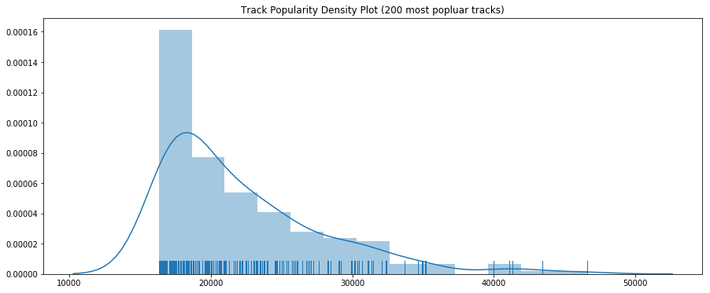

```python
fig_tracks_pop, ax_tracks_pop = plt.subplots(figsize=(15,6))
ax_tracks_pop.set_title('Track Popularity Density Plot (200 most popluar tracks)')
_ = sns.distplot(all_tracks_popularity[:200], rug=True, ax=ax_tracks_pop)
```

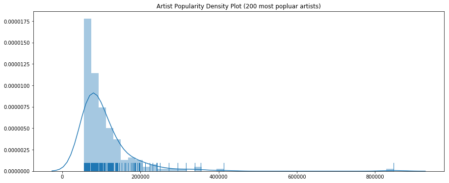

```python
fig_artists_pop, ax_artists_pop = plt.subplots(figsize=(15,6))
ax_artists_pop.set_title('Artist Popularity Density Plot (200 most popluar artists)')
_ = sns.distplot(all_artists_popularity[:200], rug=True, ax=ax_artists_pop)
```

The assumption of a high skew when it comes to popularity holds true for this data set as well. Both density distributions for tracks and artists show a few successful items and a very heavy long tail.

### Investigating the long-tail

To see how rich the long-tail really is, let's take a look at some values of rare tracks and artists.

```python
def get_longtail(full_df, ltype, title=None, cutoff=10, figsize=(6, 4)):
    """
    Investigates the longtail by creating buckets of the least popular items.

    Parameters:
    -------------
    full_df: list with popularity counts
    ltype: can be 'artist' or 'track' determining which uri-class should be investigated.
    cutoff: int that determines the amount of popularity to be deleted

    Returns:
    -------------
    None - but prints summary and plots barplot of longtail
    """
    element_buckets = []
    for i in range(1, cutoff+1):
        tmp_element_buckets = [x for x in full_df if x < i+1 and x > i-1]
        element_buckets.append(len(tmp_element_buckets))
    element_buckets.append(len([x for x in full_df if x > cutoff]))

    if ltype in ['artist', 'track']:
        print ("{:,} {}s of {:,} appear only once in a playlist ({:.2f} %). \n \
           {:,} {}s ({:.2f} %) appear {} times or fewer.".format(
        element_buckets[0],
        ltype,
        len(full_df),
        element_buckets[0] / len(full_df) * 100,
        np.sum(element_buckets[:cutoff]),
        ltype,
        np.sum(element_buckets[:cutoff]) / len(full_df) * 100,
        cutoff))
        x_label = 'Playlist appearances'
        if not title:
            title = 'Number of times an {} appears in a playlist.'.format(ltype)
    else:
        x_label = ltype

    fig_elements_longtail, ax_elements_longtail = plt.subplots(figsize=figsize)
    ax_elements_longtail.set_title(title)
    ax_elements_longtail.set_ylabel('Amount of {}s'.format(ltype))
    ax_elements_longtail.set_xlabel(x_label)
    labels = [str(x) for x in range(1,cutoff+1)]
    labels.append('>{}'.format(cutoff))
    sns.barplot(x=labels, y=element_buckets, ax=ax_elements_longtail)
```

#### The MPD-Artist Longtail

As mentioned above a feature that needs to be taken into account are skews within the data set. Any co-occurence based algorithms might fail to perform well, if there is not enough information within the item representations. Some studys have shown that using a different approach for long-tail predictions yield better performance than others. One potential way of handling these characteristics of playlist collections could be popularity based pre-filtering.

```
101,885 artists of 295,860 appear only once in a playlist (34.44 %).
            228,433 artists (77.21 %) appear 15 times or fewer.
```

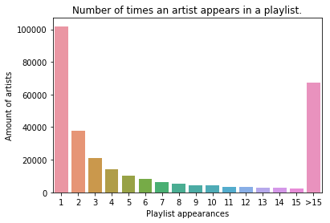

```python
get_longtail(all_artists_popularity, ltype='artist', cutoff=15)
```

More than a third of all artists appear only once in a playlist. Chances are very high that a co-occurence driven approach will heavily overfit to the one playlist this artist is in. The plot above shows another property of this particular dataset. The skews are heavy in both directions. There are a few artists that have a lot of appearances and a lot of artists that have none.

#### The MPD-Track Longtail

Similar to the characteristics of the artist distribution, the lion-share of tracks has less than 15 playlist placements. In fact the skew is a little bit more severe, which makes sense since the overall population is way larger. With less than 12 % of all tracks appearing more than 15 times in a playlist we need to find a way to model rare tracks and show their similarity to each other.

```
1,073,419 tracks of 2,262,292 appear only once in a playlist (47.45 %).
            1,993,441 tracks (88.12 %) appear 15 times or fewer.
```

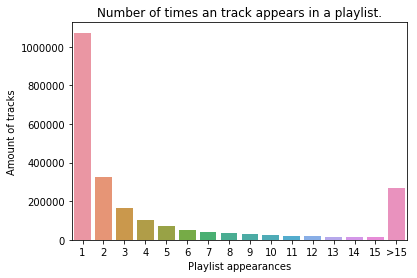

```python
get_longtail(all_tracks_popularity, ltype='track', cutoff=15)
```

## Compute Popularity Focus of Playlists

In this section the popularity of tracks and artists will be broken down on a playlist level. It might be interesting to see how popularity aggregations change per playlist and whether it plays an important role in the inner consistency of playlists. First all tracks and artists of every playlist will be matched with the earlier computed popularity score. At the same time, median and average values will be computed as well since playlists differ in length.

```python
def get_playlist_artist_track_popularity(columns,
                                         artist_popularity_dict,
                                         track_popularity_dict,
                                         playlist_collection):
    """
    Method that iterates over a playlist collection and retrieves all potential information
    to store in one list of lists. This list can be used to create a well-formed pandas
    DataFrame.

    Parameters:
    ---------------
    columns: list storing all available and additional features for playlists
    artist_popularity_dict: lookup dict for artist popularity metrics
    artist_popularity_dict: lookup dict for track popularity metrics
    playlist_collection: retrieved playlist json

    Returns:
    ---------------
    tmp_playlist_list: list of lists every list containing features of a playlist
    columns: list of column names
    """
    tmp_playlist_list = []
    for playlist in playlist_collection['playlists']:
        tmp_popularity = []
        tmp_track_pop = []
        tmp_artist_pop = []
        track_count = 0
        if not columns:
            columns = [x for x in playlist.keys() if 'tracks' not in str(x) and 'description' not in str(x)]
            columns.extend(
                ['artist_popularity', 'artist_popularity_mean', 'artist_popularity_median',
                 'track_popularity', 'track_popularity_mean', 'track_popularity_median',
                 'description', 'num_tracks'])
        tmp_playlist_features = [playlist[x] for x in playlist.keys() if 'tracks' not in str(x) and 'description' not in str(x)]
        for track in playlist['tracks']:
            track_count += 1
            artist = track['artist_uri']
            track = track['track_uri']
            tmp_artist_pop.append(artist_popularity_dict[artist])
            tmp_track_pop.append(track_popularity_dict[track])
        tmp_playlist_features.extend(
            [np.sum(tmp_artist_pop), np.mean(tmp_artist_pop), np.median(tmp_artist_pop),
             np.sum(tmp_track_pop), np.mean(tmp_track_pop), np.median(tmp_track_pop)])
        tmp_playlist_features.append(playlist['description'] if 'description' in playlist.keys() else None)
        tmp_playlist_features.append(track_count)
        tmp_playlist_list.append(tmp_playlist_features)
    return tmp_playlist_list, columns
```

```python
def get_playlist_df(recompute):
    """
    Iteration method to retrieve and store playlist features.

    Parameters:
    ----------------
    recompute:  bool flag indicating whether to load data from precomputed
                results or retrieve from json objects
    Returns:
    ----------------
    playlist_df:  DataFrame containing features of playlists
    """
    if recompute:
        playlist_popularity = []
        total_files = len(os.listdir(PLAYLIST_FOLDER))
        counter = 0
        columns = None
        for playlist_file in os.listdir(PLAYLIST_FOLDER):
            counter += 1
            clear_output(wait=True)
            print ("Working on slice {} ({:.2f} %) (File Name:  {} || Total Slices: {})".format(
                counter, (counter / total_files) * 100, playlist_file, total_files))
            playlist_collection = open_json(os.path.join(PLAYLIST_FOLDER, playlist_file))
            tmp_playlist_popularity, columns = get_playlist_artist_track_popularity(columns, artist_popularity_dict, track_popularity_dict, playlist_collection)
            playlist_popularity.extend(tmp_playlist_popularity)
        playlist_df = pd.DataFrame(playlist_popularity, columns=columns)
        playlist_df.to_csv(os.path.join(RESULTS_FOLDER, 'playlist_df.csv'))
    else:
        playlist_df = pd.read_csv(os.path.join(RESULTS_FOLDER, 'playlist_df.csv'), index_col=0)
    return playlist_df
```

```python
playlist_df = get_playlist_df(recompute)
```

```
Working on slice 1000 (100.00 %) (File Name:  mpd.slice.718000-718999.json || Total Slices: 1000)
```

```python
playlist_df.head()
```

|  | name | collaborative | pid | modified_at | num_albums | num_followers | num_edits | duration_ms | num_artists | artist_popularity | artist_popularity_mean | artist_popularity_median | track_popularity | track_popularity_mean | track_popularity_median | description | num_tracks |
| --- | --- | --- | --- | --- | --- | --- | --- | --- | --- | --- | --- | --- | --- | --- | --- | --- | --- |
| 0 | Jazz | false | 521000 | 1453593600 | 38 | 1 | 7 | 9905926 | 27 | 833854 | 20846.350000 | 14285.0 | 136491 | 3412.275000 | 1620.5 | None | 40 |
| 1 | Noosa Tastiest Playlist | false | 521001 | 1474502400 | 30 | 1 | 2 | 7784873 | 30 | 520253 | 17341.766667 | 3611.5 | 28213 | 940.433333 | 262.5 | None | 30 |
| 2 | Worship | false | 521002 | 1473638400 | 6 | 1 | 2 | 2113613 | 6 | 199232 | 33205.333333 | 24804.5 | 4404 | 734.000000 | 751.5 | None | 6 |
| 3 | CANCUN | false | 521003 | 1404777600 | 12 | 1 | 4 | 3316480 | 12 | 1070261 | 82327.769231 | 88500.0 | 45489 | 3499.153846 | 1437.0 | None | 13 |
| 4 | Dancing | false | 521004 | 1382313600 | 18 | 1 | 14 | 4540444 | 17 | 677011 | 37611.722222 | 6159.5 | 29732 | 1651.777778 | 193.5 | None | 18 |

```python
print ("The total collection stores {:,} playlists with {} features.".format(*playlist_df.shape))
```

```
The total collection stores 1,000,000 playlists with 17 features.
```

```python
playlist_df.tail()
```

|  | name | collaborative | pid | modified_at | num_albums | num_followers | num_edits | duration_ms | num_artists | artist_popularity | artist_popularity_mean | artist_popularity_median | track_popularity | track_popularity_mean | track_popularity_median | description | num_tracks |
| --- | --- | --- | --- | --- | --- | --- | --- | --- | --- | --- | --- | --- | --- | --- | --- | --- | --- |
| 999995 | workout | false | 718995 | 1508889600 | 29 | 1 | 11 | 8102214 | 23 | 3701226 | 97400.684211 | 94963.0 | 407457 | 10722.552632 | 7133.5 | None | 38 |
| 999996 | Smooth | false | 718996 | 1507852800 | 64 | 2 | 7 | 17242219 | 57 | 902406 | 13078.347826 | 4085.0 | 62090 | 899.855072 | 224.0 | The soundtrack to my life at the moment | 69 |
| 999997 | Woo | false | 718997 | 1476316800 | 85 | 3 | 10 | 21777968 | 63 | 1714262 | 16806.490196 | 4302.0 | 131693 | 1291.107843 | 108.5 | None | 102 |
| 999998 | upBEAT | false | 718998 | 1438041600 | 10 | 1 | 3 | 2326080 | 10 | 306667 | 27878.818182 | 11666.0 | 54145 | 4922.272727 | 4251.0 | None | 11 |
| 999999 | old | false | 718999 | 1508889600 | 19 | 2 | 4 | 4801889 | 14 | 707996 | 37262.947368 | 22779.0 | 156124 | 8217.052632 | 9175.0 | None | 19 |

### Popularity Distributions

Given the popularity metrics for all tracks and artists we can investigate how this feature plays a role in the total distribution. Given our first plotting attempts on popularity we expect to see a heavy skew in both features.

#### Artist Popularity

Let's take a look at mean and median values for artist popularity in playlists.

```python
playlist_df['artist_popularity_median'].describe()
```

```
count    1000000.000000
mean       42495.281276
std        54328.344621
min            1.000000
25%         8695.000000
50%        27364.000000
75%        58676.000000
max       846937.000000
Name: artist_popularity_median, dtype: float64
```

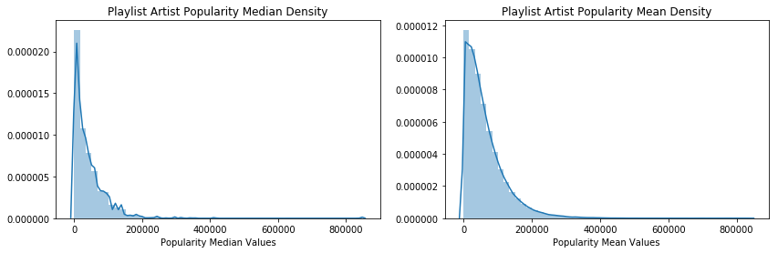

```python
fig_artist_pop_sub, ax_artist_pop_sub = plt.subplots(nrows=1, ncols=2, figsize=(14,4))
sns.distplot(playlist_df['artist_popularity_median'], ax=ax_artist_pop_sub[0])
ax_artist_pop_sub[0].set_title('Playlist Artist Popularity Median Density')
ax_artist_pop_sub[0].set_xlabel('Popularity Median Values')
sns.distplot(playlist_df['artist_popularity_mean'], ax=ax_artist_pop_sub[1])
ax_artist_pop_sub[1].set_title('Playlist Artist Popularity Mean Density')
_ = ax_artist_pop_sub[1].set_xlabel('Popularity Mean Values')
```

The median and mean value plots show tremendous right-skews. This means most playlists are comprised out of "unpopular" artists which makes sense since only a few tracks appear a lot of times in any given playlist.

#### Track Popularity

When looking at track popularity we see a similar trend.

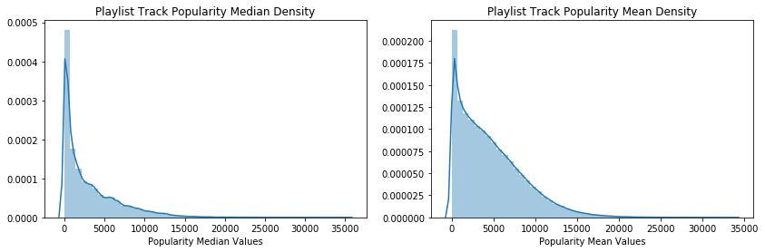

```python
fig_track_pop_sub, ax_track_pop_sub = plt.subplots(nrows=1, ncols=2, figsize=(14,4))
sns.distplot(playlist_df['track_popularity_median'], ax=ax_track_pop_sub[0])
ax_track_pop_sub[0].set_title('Playlist Track Popularity Median Density')
ax_track_pop_sub[0].set_xlabel('Popularity Median Values')
sns.distplot(playlist_df['track_popularity_mean'], ax=ax_track_pop_sub[1])
ax_track_pop_sub[1].set_title('Playlist Track Popularity Mean Density')
_ = ax_track_pop_sub[1].set_xlabel('Popularity Mean Values')
```

Yet the average density seems to have a less severe longtail which appears to be happening because of two factors:

1. The addition of one popular track to a playlist with rather unpopular track can make a huge impact on average values.
2. The range in between minimum and maximum is smaller

#### Overly popular-heavy Playlists

Let's see how overall popular-heavy playlists can be characterized.

```python
max_artist_median_playlists = playlist_df[
    playlist_df['artist_popularity_median'] == playlist_df['artist_popularity_median'].max()]
print ('The maximum median for artist popularity in a playlist is {:,} ({:,} Playlists).'.format(
    int(playlist_df['artist_popularity_median'].max()), len(max_artist_median_playlists)))
```

```
The maximum median for artist popularity in a playlist is 846,937 (1,207 Playlists).
```

This means, 1,207 playlists have a maximum median artist popularity value which is equal to the maximum poopularity value for any single artist `Drake`.

```python
max_artist_median_playlists.head()
```

|  | name | collaborative | pid | modified_at | num_albums | num_followers | num_edits | duration_ms | num_artists | artist_popularity | artist_popularity_mean | artist_popularity_median | track_popularity | track_popularity_mean | track_popularity_median | description | num_tracks |
| --- | --- | --- | --- | --- | --- | --- | --- | --- | --- | --- | --- | --- | --- | --- | --- | --- | --- |
| 411 | Sadd | false | 521411 | 1472774400 | 11 | 2 | 5 | 4906956 | 4 | 10767310 | 566700.526316 | 846937.0 | 94047 | 4949.842105 | 3713.0 | None | 19 |
| 1175 | Love | false | 175 | 1469059200 | 12 | 1 | 2 | 4337022 | 4 | 12535625 | 696423.611111 | 846937.0 | 186362 | 10353.444444 | 5821.0 | None | 18 |
| 1704 | Drake | false | 704 | 1498348800 | 96 | 1 | 46 | 55454339 | 48 | 122056465 | 554802.113636 | 846937.0 | 1290159 | 5864.359091 | 3277.0 | None | 220 |
| 2954 | Drake | false | 1954 | 1505433600 | 66 | 2 | 51 | 46406687 | 34 | 120776017 | 649333.424731 | 846937.0 | 1215664 | 6535.827957 | 3875.5 | None | 186 |
| 3040 | Rap | false | 10040 | 1508112000 | 31 | 1 | 23 | 18150207 | 23 | 36041404 | 487046.000000 | 846937.0 | 672703 | 9090.581081 | 5507.0 | None | 74 |

```python
print ('{} of those playlists have the word "Drake" in their name.'.format(
    len([x for x in max_artist_median_playlists.name if 'Drake' in x])))
```

```
431 of those playlists have the word "Drake" in their name.
```

## Feature: `collaborative`

The `collaborative` feature indicates whether a playlist is open for other people to participate.

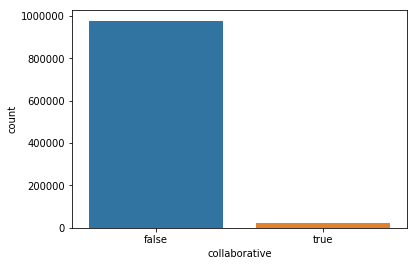

```python
_ = sns.countplot(playlist_df['collaborative'])
```

```python
coll_counts = Counter(playlist_df['collaborative'])
```

```python
print ('{:,} playlists are collaborative, {:,} are not.'.format(coll_counts[True], coll_counts[False]))
```

```
0 playlists are collaborative, 0 are not.
```

The vast majority of playlists are non-collaborative. This feature doesn't seem to move the needle significantly.

## Feature: `modified_at`

`modified_at` offers a peek into whether the playlists are rather active or inactive.

```python
def get_year_month_day(timestamp):
    dt_obj = datetime.datetime.fromtimestamp(timestamp)
    return datetime.datetime(dt_obj.year, dt_obj.month, dt_obj.day)
```

```python
get_year_month_day(1472774400)
```

```
datetime.datetime(2016, 9, 1, 0, 0)
```

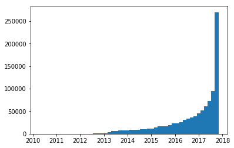

```python
_ = plt.hist([get_year_month_day(x) for x in playlist_df['modified_at']], bins=50)
```

The majority of playlists is of the recent or active kind. In fact over a quarter falls into the upper 2% (with most recent changes). There is no information about the time a playlist was generated. Something to ponder about is whether the recent change has an impact on the population in general. More recent tracks won't be appearing in playlists that have less recent changes. It might be benefitial to keep this in mind.

## Feature: `num_followers`

`num_follower` describes how many followers a playlist has. This number doesn't include the playlist owner.

```python
def get_descriptive_table(df_series):
    """
    Helper method to return descriptive stats
    about a feature in a given Series.
    """
    return pd.DataFrame(df_series.describe()).drop('count').transpose()
```

```python
get_descriptive_table(playlist_df['num_followers'])
```

|  | mean | std | min | 25% | 50% | 75% | max |
| --- | --- | --- | --- | --- | --- | --- | --- |
| num_followers | 2.597746 | 128.851145 | 1.0 | 1.0 | 1.0 | 1.0 | 71643.0 |

The distribution is very heavily skewed to the right. There are a lot of playlists with a single digit follower count. And only a few very popular playlists. The maximum is 71,643 followers.

```python
print ('The top 20 playlists attribute to {:.2f} % of all followers.'.format(
    (np.sum(sorted(playlist_df['num_followers'], reverse=True)[:20]) / playlist_df['num_followers'].sum()) * 100))
```

```
The top 20 playlists attribute to 16.69 % of all followers.
```

The cutoff value for the 99th percentile is 8 followers, which puts this in further perspective. A quick investigation of the longtail shows that my `lee & panic` playlist with 8 followers would be in the top 1 % of all playlist by popularity. Whoop whoop!

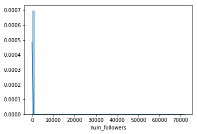

```python
_ = sns.distplot(playlist_df['num_followers'])
```

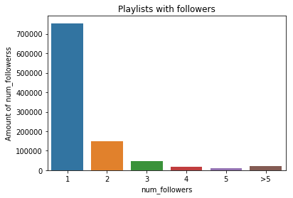

```python
get_longtail(
    playlist_df['num_followers'], ltype='num_followers', title='Playlists with followers', cutoff=5)
```

```python
one_f = playlist_df[playlist_df['num_followers'] < 2]
more_than_five = playlist_df[playlist_df['num_followers'] > 5]
print ('{:,} ({:.2f} %) playlists have 1 follower. Only {:,} ({:.2f} %) have more than 5.'.format(
    len(one_f), len(one_f) / len(playlist_df) * 100,
    len(more_than_five),
    len(more_than_five) / len(playlist_df) * 100,))
```

```
754,219 (75.42 %) playlists have 1 follower. Only 19,838 (1.98 %) have more than 5.
```

## Feature: `num_edits`

`num_edits` counts how many times a playlist owner has changed something in the playlist. The degree of change is not being mentioned but it has to be past a 2 hour window in order to count as a new edit.

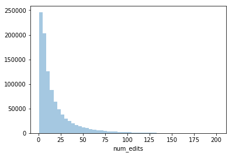

```python
_ = sns.distplot(playlist_df['num_edits'], kde=False)
```

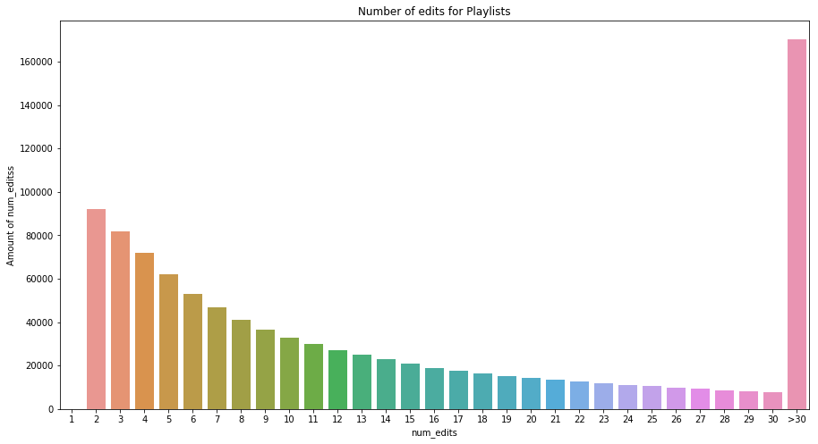

```python
get_longtail(
    playlist_df['num_edits'],
    ltype='num_edits',
    title='Number of edits for Playlists',
    cutoff=30,
    figsize=(15, 8))
```

## Feature: `duration_ms`

Another available feature is the length of a playlist in milliseconds. The interesting fact of this feature is, that while the prediction task will be based on a sequence and some of the tracks will be omitted, this feature (when not transformed while removing tracks) offers insights into the future. For now we'll treat this feature as any other feature but when omitting songs and predicting new ones, this might be an interesting tweaking opportunity.

```python
def get_minutes(h):
    return int((h * 1000) % 1000 / 1000 * 60)
```

```python
get_descriptive_table((playlist_df['duration_ms'] / 1000 / 60).apply(round, args=(2, )))  # in minutes
```

|  | mean | std | min | 25% | 50% | 75% | max |
| --- | --- | --- | --- | --- | --- | --- | --- |
| duration_ms | 259.661284 | 214.273917 | 1.63 | 99.92 | 190.37 | 357.23 | 10584.56 |

To make it a bit more descriptive we'll transform the amount in minutes. There are a few interesting points:

- The shortest playlist is just around 1 1/2 minutes long.
- The longest playlist has a play time of over 176 hours or >7 days.

```python
duration_plot = [x for x in (playlist_df['duration_ms'] / 1000 / 60).astype(int) if x <= 1500]
```

```python
print ('There are {:,} playlists that are longer than 1,500 minutes.'.format(
    len([x for x in (playlist_df['duration_ms'] / 1000 / 60).astype(int) if x >= 1500])))
```

```
There are 113 playlists that are longer than 1,500 minutes.
```

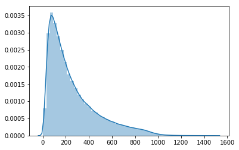

```python
_ = sns.distplot(duration_plot)
```

Overall there is a right skew in the distribution. The most playlists seem to range between 50 to 300 minutes.

```python
print ('The median length of all playlist is {:.2f} minutes.'.format(
    playlist_df['duration_ms'].median() / 1000 / 60))
```

```
The median length of all playlist is 190.37 minutes.
```

Let's investigate and see what outlier playlists look like.

```python
max_duration_tracks = get_playlist(
    playlist_df[playlist_df['duration_ms'] == playlist_df['duration_ms'].max()].pid.values[0], True)
```

```python
min_duration_tracks = get_playlist(
    playlist_df[playlist_df['duration_ms'] == playlist_df['duration_ms'].min()].pid.values[0], True)
```

#### Longest Playlist

```python
total_length = 0
duration_dict = {}
for track in max_duration_tracks:
    hours_dec = track['duration_ms'] / 1000 / 60 / 60
    #print (get_minutes(hours_dec))
    duration_dict[track['track_name']] = str(int(hours_dec)) + 'h ' + str(get_minutes(hours_dec)) + 'm'
    total_length += track['duration_ms']
```

```python
playlist_df[playlist_df['duration_ms'] == playlist_df['duration_ms'].max()]
```

|  | name | collaborative | pid | modified_at | num_albums | num_followers | num_edits | duration_ms | num_artists | artist_popularity | artist_popularity_mean | artist_popularity_median | track_popularity | track_popularity_mean | track_popularity_median | description | num_tracks |
| --- | --- | --- | --- | --- | --- | --- | --- | --- | --- | --- | --- | --- | --- | --- | --- | --- | --- |
| 512062 | sets | false | 397062 | 1412121600 | 119 | 1 | 52 | 635073792 | 116 | 289155 | 1338.680556 | 37.0 | 429 | 1.986111 | 1.0 | None | 216 |

```python
Counter(duration_dict).most_common(10)
```

```
[('Utilities - Recorded - Part 2 - Continuous DJ Mix', '1h 9m'),
 ('Amnesia DJ Sessions Ibiza, Vol. 8 - DJ Mix By Sander Kleinenberg', '1h 9m'),
 ('DJ Mix 1', '1h 9m'),
 ('Phonosythesis (Continuous DJ Mix)', '1h 9m'),
 ("Release Yourself '11 - CD1 - Continuous DJ Mix", '1h 9m'),
 ('Continuous Mix 4 by Vinyl Junkie - Continuous DJ Mix 4', '1h 9m'),
 ('Renaissance - The Mix Collection - Part 2 - Downside Up - Continuous DJ Mix',
  '1h 9m'),
 ('The Sound Of Renaissance - Volume 1 - Part 1 - Continuous DJ Mix', '1h 8m'),
 ('Renaissance - The Mix Collection - Part 1 - Upside Down - Continuous DJ Mix',
  '1h 8m'),
 ('Disco Rodeo - Continuous Mix By DJ Icey', '1h 7m')]
```

This playlist seems to be a collection of electronic DJ sets. These DJ sets can be seen as playlists themselves. This might be a fun side-project, to investigate new DJ sets and their track playlists for people who want to listen to the latest and hottest tracks.

#### Shortest Playlist

```python
min_duration_tracks
```

```
[{'album_name': 'The Tonight Show Band With Doc Severinsen',
  'album_uri': 'spotify:album:77hahRer2KgREc1JBcQIsz',
  'artist_name': 'Doc Severinsen',
  'artist_uri': 'spotify:artist:36qxqKuaIzIOC8tLgTy02Z',
  'duration_ms': 77826,
  'pos': 0,
  'track_name': "Johnny's Theme - The Tonight Show Theme",
  'track_uri': 'spotify:track:2iT6ORp4HmVWHjEP7vCanD'},
 {'album_name': 'People Sound Effects 1',
  'album_uri': 'spotify:album:0EnRFbH1jv06LdfYfJZdfr',
  'artist_name': 'Finnolia Sound Effects',
  'artist_uri': 'spotify:artist:7piUznRWxNyKpaPvmOSdiZ',
  'duration_ms': 7006,
  'pos': 1,
  'track_name': 'Applause (Version 1) [People Clapping Hands Audience Crowd Applauding Noise] [Sound Effect]',
  'track_uri': 'spotify:track:2UdbbEkZes5gGf0ErW4n6J'},
 {'album_name': 'Essential Sound Effects 7 - Miscellaneous Sound Effects',
  'album_uri': 'spotify:album:0MNonRlUrJf54ubpV7sI3F',
  'artist_name': 'Essential Sound Effects',
  'artist_uri': 'spotify:artist:3JyAQuSJuybJb4tLtCFGqK',
  'duration_ms': 6706,
  'pos': 2,
  'track_name': 'Applause Crowd Group Small Theatre Audience People Clapping Clap Hands Sound Effects Sound Effect Crowd Sounds Applause',
  'track_uri': 'spotify:track:6s0sIjvghDHxBt9Ui63WQV'},
 {'album_name': 'Sound Effects, Vol. 2',
  'album_uri': 'spotify:album:7hmxb4D5JDiPXd4DCe51ek',
  'artist_name': 'DV Sound Effects',
  'artist_uri': 'spotify:artist:0JZXn8DdLAevkhyHwbswBF',
  'duration_ms': 3000,
  'pos': 3,
  'track_name': 'Crowd Laughter (Version 3) [People Laughing Laugh Audience Group Noise Sfx Sound Effect Bite Clip Fx]',
  'track_uri': 'spotify:track:6OzEKlxPck3hlYlD8i7ns0'},
 {'album_name': 'Animals, Short Sound Effects',
  'album_uri': 'spotify:album:5qpR0qyRVxxMM0UH1TqHlO',
  'artist_name': 'Text Sound Effects',
  'artist_uri': 'spotify:artist:2l45CJMYMHoKm6nUYlbJy3',
  'duration_ms': 3000,
  'pos': 4,
  'track_name': 'Cricket Chirps',
  'track_uri': 'spotify:track:0ewEcMimm3m6pxdGXDDhLz'}]
```

The playlist with the shortest `duration_ms` value contains sound effects and jingles.

```python
playlist_df[playlist_df['duration_ms'] == playlist_df['duration_ms'].min()]
```

|  | name | collaborative | pid | modified_at | num_albums | num_followers | num_edits | duration_ms | num_artists | artist_popularity | artist_popularity_mean | artist_popularity_median | track_popularity | track_popularity_mean | track_popularity_median | description | num_tracks |
| --- | --- | --- | --- | --- | --- | --- | --- | --- | --- | --- | --- | --- | --- | --- | --- | --- | --- |
| 731170 | video | false | 479170 | 1420156800 | 5 | 1 | 2 | 97538 | 5 | 114 | 22.8 | 3.0 | 10 | 2.0 | 1.0 | None | 5 |

## New Feature: `ms_mean`

Given the amount of tracks and the length of the playlist we can estimate the length of each element in a playlist. This might be an indicator for a certain type of playlist (i.e. radio edits, dj sets, etc.)

```python
ms_mean = playlist_df['duration_ms'] / playlist_df['num_tracks']
```

```python
playlist_df['ms_mean'] = ms_mean
```

```python
ms_mean = ms_mean / 1000
```

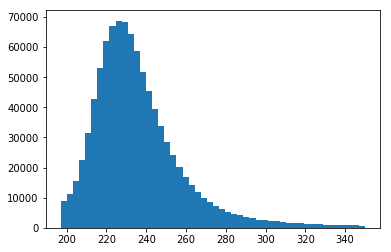

```python
_ = plt.hist(ms_mean, bins=50, range=(ms_mean.quantile(.05), ms_mean.quantile(.99)))
```

```python
len(playlist_df[(playlist_df['ms_mean'] >= 220 * 1000) & (playlist_df['ms_mean'] <= 250 * 1000)])
```

```
538746
```

#### Did radio get it wrong all these years?

The density population of `ms_mean` indicates most playlists are comprised out of tracks that range from 220 to 250 seconds. In radio format-terms this is actually longer than expected.

## Feature: `num_artists`

Let's take a look at the number of artists that are within the playlist collections.

```python
get_descriptive_table(playlist_df['num_artists'])
```

|  | mean | std | min | 25% | 50% | 75% | max |
| --- | --- | --- | --- | --- | --- | --- | --- |
| num_artists | 38.088211 | 30.282901 | 3.0 | 16.0 | 29.0 | 52.0 | 238.0 |

We know, Spotify did some preliminary filtering to remove one-artist playlists. The MPD therefore contains playlists with an average of 38 different artists per playlist. Ranging from a minimum of 3 up to a maximum of 238.

```python
playlist_df[playlist_df['num_artists'] == 238]
```

|  | name | collaborative | pid | modified_at | num_albums | num_followers | num_edits | duration_ms | num_artists | artist_popularity | artist_popularity_mean | artist_popularity_median | track_popularity | track_popularity_mean | track_popularity_median | description | num_tracks | ms_mean |
| --- | --- | --- | --- | --- | --- | --- | --- | --- | --- | --- | --- | --- | --- | --- | --- | --- | --- | --- |
| 807985 | LIT | false | 368985 | 1486512000 | 241 | 1 | 36 | 52964903 | 238 | 1792125 | 7405.475207 | 247.5 | 124158 | 513.049587 | 17.5 | None | 242 | 218863.235537 |
| 857712 | 90s | false | 544712 | 1455753600 | 239 | 10 | 16 | 59649777 | 238 | 2578851 | 10745.212500 | 3294.0 | 359737 | 1498.904167 | 534.0 | None | 240 | 248540.737500 |

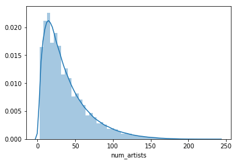

```python
_ = sns.distplot(playlist_df['num_artists'])
```

## Feature: `num_tracks`

Investigating both density plots for number of tracks and number of artists, they seem to be fairly similar. The largest difference might be a harsh drop in density around 250 unique tracks. Other than that, `num_tracks` density almost behaves like a multiple of `num_artists`.

```python
get_descriptive_table(playlist_df['num_tracks'])
```

|  | mean | std | min | 25% | 50% | 75% | max |
| --- | --- | --- | --- | --- | --- | --- | --- |
| num_tracks | 66.346428 | 53.669358 | 5.0 | 26.0 | 49.0 | 92.0 | 376.0 |

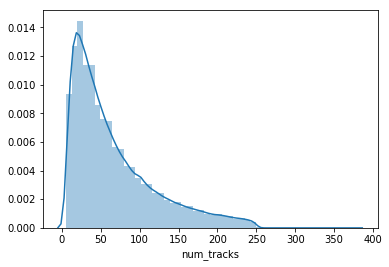

```python
_ = sns.distplot(playlist_df['num_tracks'])
```

## Feature: `num_albums`

Let's take a look at the amount of different albums that are in a playlist.

```python
get_descriptive_table(playlist_df['num_albums'])
```

|  | mean | std | min | 25% | 50% | 75% | max |
| --- | --- | --- | --- | --- | --- | --- | --- |
| num_albums | 49.597278 | 39.961064 | 2.0 | 20.0 | 37.0 | 68.0 | 244.0 |

The information within this feature is fairly close to `num_tracks` and `num_artists`.

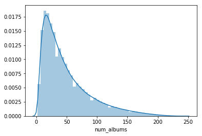

```python
_ = sns.distplot(playlist_df['num_albums'])
```

A quick investigation regarding the relationship of `num_albums`, `num_tracks` and `num_artists` shows a potential correlation between all of these.

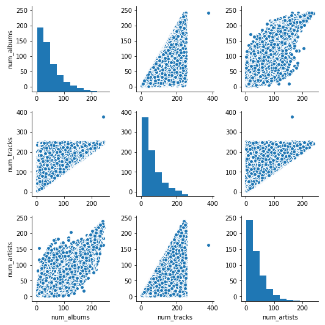

```python
_ = sns.pairplot(playlist_df[['num_albums', 'num_tracks', 'num_artists']])
```

To validate these visual clues we'll be taking a pearson test between the populations.

```python
feature_list = ['num_albums', 'num_tracks']
for feature in feature_list:
    corr, p_val = stats.pearsonr(playlist_df['num_artists'], playlist_df[feature])
    print ('num_artists -> {}: correleation: {:.3f} (p: {})'.format(feature, corr, p_val))
corr, p_val = stats.pearsonr(playlist_df[feature_list[0]], playlist_df[feature_list[1]])
print ('{} -> {}: correleation: {:.3f} (p: {})'.format(feature_list[0], feature_list[1],
    corr, p_val))
```

```
num_artists -> num_albums: correleation: 0.956 (p: 0.0)
num_artists -> num_tracks: correleation: 0.818 (p: 0.0)
num_albums -> num_tracks: correleation: 0.900 (p: 0.0)
```

The calculations verify a strong and highly significant correlation between those features. It looks like following statements hold true:

- A playlist with a high number of artists has a higher number of albums
- Playlists that have a higher number of artists have more tracks
- Playlists that hold more individual albums hold more individual tracks

We therefore might be able to compress some of this information down the road if needed.

## Investigate Text Information

Next to numerical information, there is textual input that could be helpful. Two features in the dataset have text information capturing title or `name` and `description` of a playlist. In this section we'll be looking at the content of those features in more detail.

## Feature: `name`

The name feature gives a playlist owner the chance to link a certain theme or topic with a playlist. Usually those names are quite brief and limited to 100 characters.

```python
print ('There are {:,} unique playlist-names in the playlist collection.'.format(
    len(playlist_df['name'].unique())))
```

```
There are 92,944 unique playlist-names in the playlist collection.
```

```python
title_lengths = [len(str(x)) for x in playlist_df['name'].values]
```

```python
print ('The average length is: {:.3f} (+/- {:.2f}) | median: {}\nThe maximum is {} chars the minimum is {}.'.format(
    np.mean(title_lengths), np.std(title_lengths), np.median(title_lengths),
    np.max(title_lengths), np.min(title_lengths)))
```

```
The average length is: 7.686 (+/- 4.13) | median: 7.0
The maximum is 100 chars the minimum is 2.
```

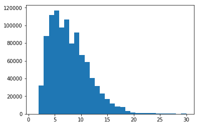

```python
_ = plt.hist(title_lengths, bins=30, range=(1, 30))
```

```python
print ('Only {:.3f} % of all playlist names have more than 30 characters.'.format(
    len([x for x in title_lengths if x > 30]) / len(playlist_df) * 100))
```

```
Only 0.177 % of all playlist names have more than 30 characters.
```

The descriptive amount of those playlists seems limited to only a few characters. Most playlist names range around 7 characters.

### Emojis

Some playlist names have emojis in them. Since emojis are a nice way of capturing the mood, it might be interesting to see some statistics regarding their usage.

```python
topics = [str(x).lower() for x in playlist_df['name']]
```

```python
def find_emojis(topic_list):
    emoji_to_idx = {}
    total_count = 0
    emoji_counts = {}
    for idx, s in enumerate(topic_list):
        ems = re.findall(u'[\U0001f600-\U0001f650]', s)
        count = len(ems)
        for e in ems:
            count_or_one(emoji_counts, e)
            if e in emoji_to_idx:
                if idx not in emoji_to_idx[e]:
                    emoji_to_idx[e].append(idx)
            else:
                emoji_to_idx[e] = [idx]
        total_count += count
    return emoji_counts, emoji_to_idx, total_count
```

```python
emoji_dict, emoji_to_idx, emoji_count = find_emojis(topics)
```

```python
print ('There are a total of {:,} emojis in all titles.'.format(emoji_count))
```

```
There are a total of 3,579 emojis in all titles.
```

This also takes into account multiple emojis in one playlist name for now. Let's see which emojis are the most frequent ones.

```python
def get_playlist_with_emoji_in_header(emoji_to_idx, emoji):
    return playlist_df[playlist_df.index.isin(emoji_to_idx[emoji])]
```

```python
most_common_emojis = Counter(emoji_dict).most_common(15)
```

```python
most_common_emojis
```

```
[('😍', 809),
 ('😈', 316),
 ('😴', 311),
 ('😎', 274),
 ('😛', 247),
 ('😏', 193),
 ('🙌', 180),
 ('🙏', 131),
 ('😻', 123),
 ('😭', 121),
 ('😇', 113),
 ('😊', 100),
 ('😌', 100),
 ('😜', 95),
 ('🙃', 91)]
```

It is actually quite interesting to see that just by looking at the top 15 emojis you might already infer some "feeling" as to what songs should be in there.

- 😍 $\rightarrow$ love
- 😴 $\rightarrow$ sleep/relax
- 😭 $\rightarrow$ sadness
- 🙌 $\rightarrow$ upbeat/whoopwhoop ...
- 😜 $\rightarrow$ not really my music taste

```python
love_playlists = get_playlist_with_emoji_in_header(emoji_to_idx, '😍')
rock_playlists = get_playlist_with_emoji_in_header(emoji_to_idx, '😈')
sleep_playlists = get_playlist_with_emoji_in_header(emoji_to_idx, '😴')
party_playlists = get_playlist_with_emoji_in_header(emoji_to_idx, '🙌')
```

This might be a good starting point for mood-based semi-supervised classification.

### Tokens

Next let's have a closer look at the words that are stored away in the `name` feature. We'll remove stopwords (might have to add music specific stopwords such as `playlist` or `music`) first, tokenize and lemmatize. All words have been lowered in a previous step already to get a better grasp on unique words. Afterwards we'll deal with some preliminary frequency analysis.

```python
engl_stopwords = nltk.corpus.stopwords.words('english')
```

```python
tokenizer = nltk.tokenize.RegexpTokenizer(r'\w+')
```

```python
lemmatizer = nltk.WordNetLemmatizer()
```

```python
token_dict = {}
lemma_to_word = {}
for t in topics:
    tokens = [x for x in tokenizer.tokenize(t) if x not in engl_stopwords]
    for token in tokens:
        lemma = lemmatizer.lemmatize(token)
        lemma_to_word[lemma] = token
        count_or_one(token_dict, lemma)
```

```python
print ('There are {:,} unique tokens in the playlist titles.'.format(len(token_dict)))
```

```
There are 10,091 unique tokens in the playlist titles.
```

```python
most_common_tokens = Counter(token_dict).most_common(20)
```

```python
def plot_most_common_obj(most_common_obj):
    bp_x = [x[0] for x in most_common_obj]
    bp_y = [x[1] for x in most_common_obj]
    fig_bp, ax_bp = plt.subplots(figsize=(15,8))
    for tick in ax_bp.get_xticklabels():
        tick.set_rotation(45)
    sns.barplot(x=bp_x, y=bp_y, ax=ax_bp)
```

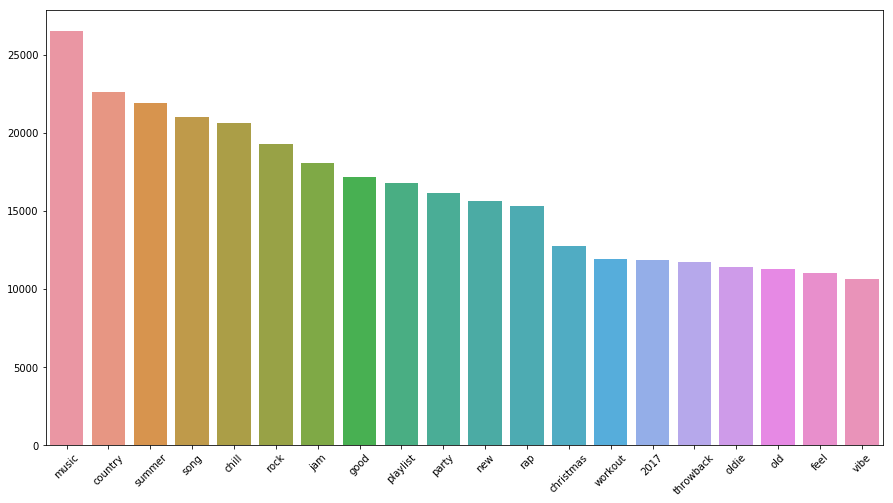

```python
plot_most_common_obj(most_common_tokens)
```

This is very interesting already. Nebst to some generic information such as music and playlist we seem to see some classes of playlists appear. Yet, it might be interesting to see how these tokens behave if we determine the tf-idf score per playlist title. This might be helpful to upweight some of the rare and descriptive words.

#### TF-IDF

The [tf-idf](https://en.wikipedia.org/wiki/Tf–idf) score determines the importance of a term in a given document (in our case the title or description) for that document with respect of its frequency in the overall corpus. Since we're dealing with a slim amount of information in the titles and a sparse dataset with regards of descriptions it might be tough to leverage this method completely. Nevertheless, we'll perform a quick preprocessing and tf-idf scoring to see whether there are some interesting results in the titles.

```python
def preprocess_text_to_lemmas(topics):
    """
    Turns list of documents in to list of lemmas by removing stopwords,
    lowering, tokenizing and lemmatizing the words.

    Parameters:
    --------------
    topics:        list of documents

    Returns:
    --------------
    return_list:   list of lemmas
    """
    engl_stopwords = nltk.corpus.stopwords.words('english')
    return_list = []
    topics = [x.lower() for x in topics]
    for t in topics:
        tokens = [x for x in tokenizer.tokenize(t) if x not in engl_stopwords]
        for idx, token in enumerate(tokens):
            tokens[idx] = lemmatizer.lemmatize(token)
        return_list.append(tokens)
    return return_list
```

```python
lemma_list = preprocess_text_to_lemmas(topics)
```

```python
def get_tf_idf(documents, verbose=False):
    """
    Calculate tf-idf score of list of documents.

    Parameters:
    --------------
    documents:      list of documents

    Returns:
    --------------
    term_to_pids:                    dict mapping a certain term to a list of ids in which it occurs
    document_corpus_frequencies:     dict counting the appearance of a term per document (once per doc)
    document_term_frequencies:       dict counting the term frequency in total
    tfidf_doc_score:                 dict mapping a document id to the term: tf-idf score dictionary
    """
    document_corpus_frequencies = {}
    document_term_frequencies = {}
    term_to_pids = {}

    for idx, doc in enumerate(documents):
        document_term_frequencies[idx] = {}
        for token in doc:
            if token not in document_term_frequencies[idx]:
                if token in term_to_pids:
                    term_to_pids[token].append(idx)
                else:
                    term_to_pids[token] = [idx]
                # make sure there is only one occurance per word
                count_or_one(document_corpus_frequencies, token)
            count_or_one(document_term_frequencies[idx], token)

    tfidf_doc_score = {}
    for doc_idx in document_term_frequencies:
        doc = document_term_frequencies[doc_idx]
        for term in doc:
            tf = doc[term] / (len(documents[doc_idx]))
            idf = np.log10(len(document_term_frequencies) / document_corpus_frequencies[term])
            tfidf = tf * idf
            if verbose:
                print ('term: "{}"\ntf_calc: {}/{}\ntf_val: {}'.format(
                    term, doc[term], len(documents[doc_idx]), tf))
                print ('idf_calc: np.log({}/{})\nidf_val: {}'.format(
                    len(document_term_frequencies),document_corpus_frequencies[term],idf))
                print ('tfidf: {}\n'.format(tfidf))
            if doc_idx not in tfidf_doc_score:
                tfidf_doc_score[doc_idx] = {}
            tfidf_doc_score[doc_idx][term] = tfidf
    return term_to_pids, document_corpus_frequencies, document_term_frequencies, tfidf_doc_score
```

```python
term_to_pid, test_corpus_frequencies, test_term_frequencies, test_tfidf_doc_score = get_tf_idf(
    [['this', 'is', 'a', 'a', 'sample'], ['this', 'is', 'another', 'another', 'example', 'example', 'example']])
```

```python
test_tfidf_doc_score
```

```
{0: {'a': 0.12041199826559248,
  'is': 0.0,
  'sample': 0.06020599913279624,
  'this': 0.0},
 1: {'another': 0.08600857018970891,
  'example': 0.12901285528456335,
  'is': 0.0,
  'this': 0.0}}
```

```python
document_term_to_pid, document_corpus_frequencies, document_term_frequencies, tfidf_doc_score = get_tf_idf(lemma_list)
```

```python
def get_pids_from_title_lemma(lemma):
    """
    Since lemma ids and pids are off, this is a simple conversion method
    using the playlist DataFrame as a lookup table based on indices.

    Parameter:
    -------------
    lemma:       string representation of token or lemma

    Returns:
    -------------
    pid_list:    list of playlist ids
    """
    return playlist_df[
        playlist_df.index.isin(document_term_to_pid[lemma])].pid.values
```

To get an overview of the most defining terms, we'll sum the tf-idf scores up. A higher tf-idf score for a term associates more meaning and uniqueness.

```python
most_defining = {}
for doc_id in tfidf_doc_score:
    for term in tfidf_doc_score[doc_id]:
        if term in most_defining:
            most_defining[term] += tfidf_doc_score[doc_id][term]
        else:
            most_defining[term] = tfidf_doc_score[doc_id][term]
```

```python
tf_idf_themes = Counter(most_defining).most_common(20)
```

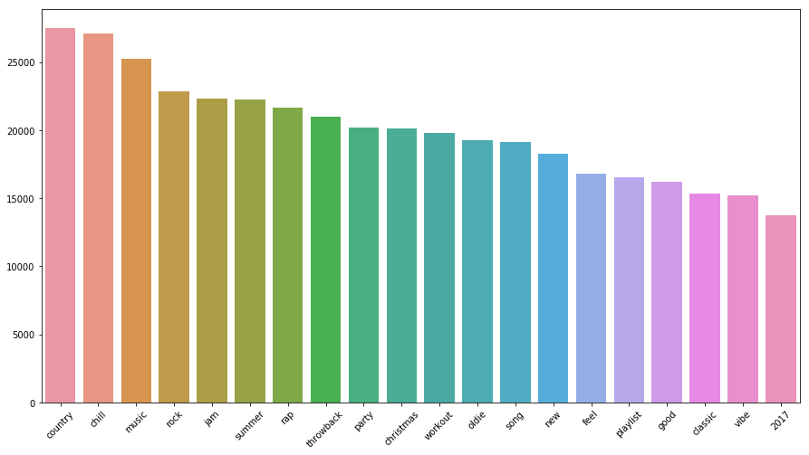

```python
plot_most_common_obj(tf_idf_themes)
```

It's interesting to see that the categories or tf-idf terms look a bit more balanced. This could be connected to the logarithmic scaling that takes place in the tf-idf scoring. More generic terms such as music, song and playlist are moving down the list of importance but still made the top 20. It could be benefitial to add some playlist-specific stop-words to negate these appearances. In addition, bigrams are missing from this observation.

```python
get_pids_from_title_lemma('chill')[0]
```

```
521193
```

```python
get_playlist(get_pids_from_title_lemma('chill')[0])['pid']
```

```
521193
```

```python
get_playlist(get_pids_from_title_lemma('country')[random.randint(0,len(get_pids_from_title_lemma('country')))])['name']
```

```
'country '
```

### Bigrams

Next we'll investigate bigrams for all titles. Since we know, that the average length of a title is somewhere around 7 characters the information gain from this exercise might be low but since some of the high-ranking tf-idf terms seem chopped it might be interesting to see how this pans out.

```python
def get_most_common_bigrams(lemmas):
    """
    Constructs bigrams based on list of lemmas.
    """
    bigrams_dict = {}
    for doc_idx, doc in enumerate(lemmas):
        bigrams = []
        for idx in range(len(doc)-1):
            bigrams.append(doc[idx] + '_' + doc[idx+1])
        if bigrams:
            bigrams_dict[doc_idx] = bigrams
    return bigrams_dict
```

```python
all_bigrams = get_most_common_bigrams(lemma_list)
```

```python
most_important_bigrams = {}
for doc_idx in all_bigrams:
    for bigram in all_bigrams[doc_idx]:
        count_or_one(most_important_bigrams, bigram)
```

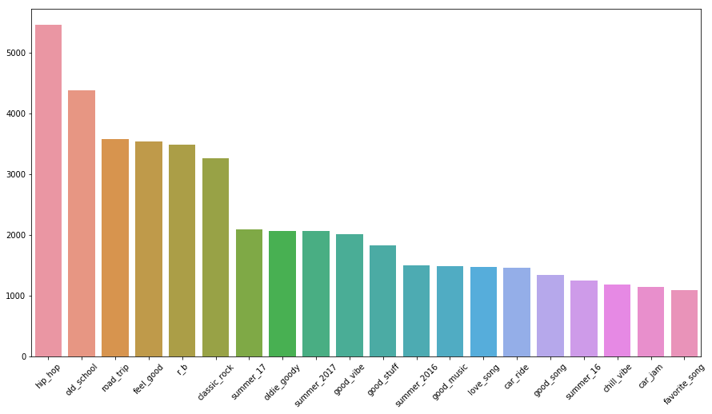

```python
plot_most_common_obj(Counter(most_important_bigrams).most_common(20))
```

The bigram analysis shows some very interesting combinations. In fact all these important bigrams make sense from a genre an theme perspective. But with hip_hop and old_school being the clear frontrunner and a frequency around 5000 mentions those bigrams wouldn't make it in the top 20 of all terms.

```python
most_defining['hip']
```

```
5658.800404527684
```

```python
most_defining['hop']
```

```
5737.37428590094
```

```python
most_defining['old']
```

```
11365.085778373583
```

```python
most_defining['school']
```

```
7712.775864007309
```

In fact, when looking at the frequencies regarding the single terms - `hip` and `hop` have almost the same tf-idf rankings (inidcating a similar importance through a strong co-occurence).

## Feature: `description`

To dive a little bit deeper into all available text information we'll be investigating the `description` feature.

```python
playlists_with_description = playlist_df[playlist_df.description.notnull()].copy()
playlists_with_description.head()
```

|  | name | collaborative | pid | modified_at | num_albums | num_followers | num_edits | duration_ms | num_artists | artist_popularity | artist_popularity_mean | artist_popularity_median | track_popularity | track_popularity_mean | track_popularity_median | description | num_tracks | ms_mean |
| --- | --- | --- | --- | --- | --- | --- | --- | --- | --- | --- | --- | --- | --- | --- | --- | --- | --- | --- |
| 37 | I Put A Spell on You | false | 521037 | 1509321600 | 72 | 3 | 6 | 16169257 | 67 | 1870022 | 25616.739726 | 5310.0 | 234014 | 3205.671233 | 954.0 | It&#x27;s just a bunch of &quot;hocus pocus&qu... | 73 | 221496.671233 |
| 180 | la flame | false | 521180 | 1506384000 | 8 | 1 | 2 | 6290939 | 3 | 3296468 | 137352.833333 | 139928.0 | 124925 | 5205.208333 | 2020.5 | $$$$$$ | 24 | 262122.458333 |
| 264 | Favorits | false | 521264 | 1506384000 | 19 | 1 | 5 | 5677626 | 12 | 131890 | 5995.000000 | 2241.0 | 8928 | 405.818182 | 61.0 | songs that just. . . Rock! | 22 | 258073.909091 |
| 269 | Simplicity | false | 521269 | 1509062400 | 129 | 6 | 95 | 34100621 | 110 | 3443511 | 23110.812081 | 4715.0 | 266697 | 1789.912752 | 330.0 | all indie folk. great roadtrip&#x2F;background... | 149 | 228863.228188 |
| 352 | garage | false | 521352 | 1479168000 | 69 | 1 | 6 | 19113665 | 39 | 1443635 | 13748.904762 | 2770.0 | 56596 | 539.009524 | 162.0 | Pure, epic garage rock ranging from the 60s to... | 105 | 182034.904762 |

```python
print ('There are {:,} playlists with description.'.format(len(playlists_with_description)))
```

```
There are 18,760 playlists with description.
```

Unfortunately there aren't too many playlists with a description. In fact, less than 2 % of all playlists have a description.

```python
desc_lengths = [len(str(x)) for x in playlists_with_description['description'].values]
```

```python
print ('The average length is: {:.3f} (+/- {:.2f}) | median: {}\nThe maximum is {} chars the minimum is {}.'.format(
    np.mean(desc_lengths), np.std(desc_lengths), np.median(desc_lengths),
    np.max(desc_lengths), np.min(desc_lengths)))
```

```
The average length is: 45.852 (+/- 46.74) | median: 31.0
The maximum is 440 chars the minimum is 0.
```

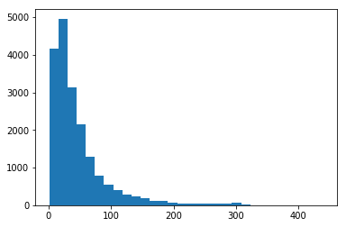

```python
_ = plt.hist(desc_lengths, bins=30, range=(1, 440))
```

```python
print ('Only {:.3f} % of all playlist names have more than 30 characters.'.format(
    len([x for x in desc_lengths if x > 30]) / len(playlist_df) * 100))
```

```
Only 0.963 % of all playlist names have more than 30 characters.
```

When it comes to information within those description, only shy of 1 percent have more than 30 characters. The median being 31, while the maximum is at 440 chars.

```python
# transform html tokens and turn into lower case
description_list = [html.unescape(str(x).lower()) for x in playlists_with_description['description']]
```

```python
# tokenize an lemmatize
description_tokens = {}
for description in description_list:
    tokens = [x for x in tokenizer.tokenize(description) if x not in engl_stopwords]
    for token in tokens:
        token = lemmatizer.lemmatize(token)
        count_or_one(description_tokens, token)
```

```python
mc_desc_tokens = Counter(description_tokens).most_common(25)
```

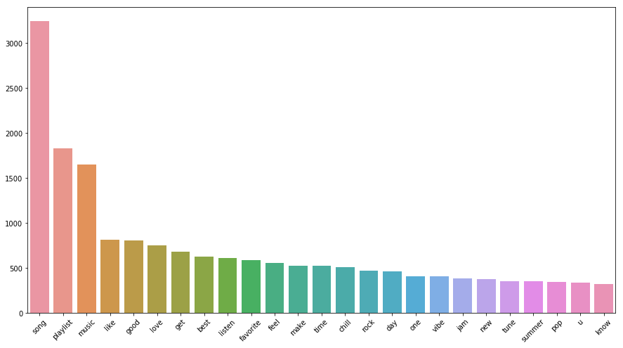

```python
plot_most_common_obj(mc_desc_tokens)
```

If we look at the most frequent terms we end up with a list of generic words that don't seem to offer too much info.

```python
description_emoji_dict, description_emoji_to_pid, description_emoji_count = find_emojis(description_list)
```

```python
Counter(description_emoji_dict).most_common(10)
```

```
[('😤', 18),
 ('😉', 4),
 ('😭', 4),
 ('😏', 3),
 ('😍', 3),
 ('😊', 3),
 ('🙌', 3),
 ('😜', 3),
 ('😝', 2),
 ('😴', 2)]
```

```python
print ('There are a total of {:,} emojis in all descriptions.'.format(description_emoji_count))
```

```
There are a total of 63 emojis in all descriptions.
```

Not too much information there either.

```python
def print_descriptions_of_playlists_with_emoji(emoji):
    emoji_descs = playlist_df[playlist_df.index.isin(
        playlists_with_description['description'].keys()[description_emoji_to_pid[emoji]])]['description'].values
    for playlist in emoji_descs:
        print (playlist)
```

```python
print_descriptions_of_playlists_with_emoji('😤')
```

```
best of the best.  I&#x27;m a bandwagon Logic fan and Andrew is a real logic fan.  FAXXXXXXXX 😤😤😤😤😤😤😤😤😤😤😤😤😤😤😤😤😤😤💉
```

Checking out some of the descriptions shows that the multi-use of emojis doesn't really add too much information to those pieces.

#### TF-IDF

Let's see what tf-idf scores look like in the description. Based on our frequency calculation this might not work too well either.

```python
description_lemmas = preprocess_text_to_lemmas(description_list)
```

```python
desc_term_to_pids, desc_corpus_frequencies, desc_term_frequencies, desc_tfidf_doc_score = get_tf_idf(description_lemmas)
```

```python
desc_most_defining = {}
for doc_id in desc_tfidf_doc_score:
    for term in desc_tfidf_doc_score[doc_id]:
        if term in desc_most_defining:
            desc_most_defining[term] += desc_tfidf_doc_score[doc_id][term]
        else:
            desc_most_defining[term] = desc_tfidf_doc_score[doc_id][term]
```

```python
desc_most_common_tfidf = Counter(desc_most_defining).most_common(20)
```

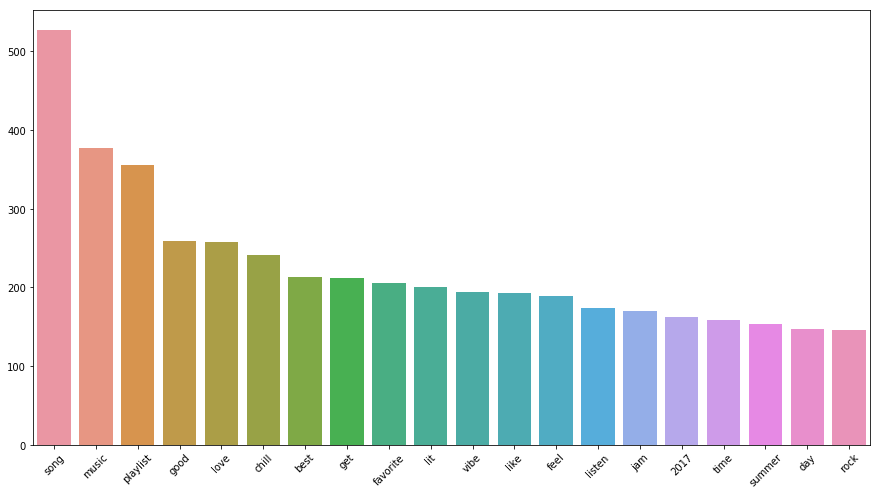

```python
plot_most_common_obj(desc_most_common_tfidf)
```

As suspected, the most defining words are the most generic as well. `song`, `music` and `playlist` are not exactly the most unique words when talking about music, moods and collections.

#### Bigrams

Let's see if looking at bigrams can shed some more light on those descriptions.

```python
desc_bigrams = get_most_common_bigrams(description_lemmas)
```

```python
desc_most_important_bigrams = {}
for doc_idx in desc_bigrams:
    for bigram in desc_bigrams[doc_idx]:
        count_or_one(desc_most_important_bigrams, bigram)
```

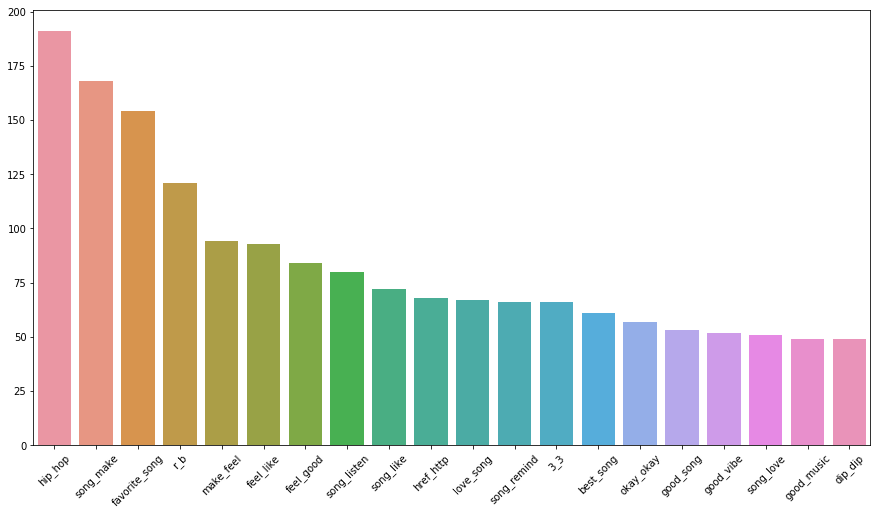

```python
plot_most_common_obj(Counter(desc_most_important_bigrams).most_common(20))
```

If it wasn't for the low counts, bigram frequencies seem to actually hold more information than the unigram frequencies. Yet the description information seems to be of little use so far for the recommendation task.

## Bi-Variate View

We already observed some strong correlations. To gain a better understanding about some of the relationships within the features we'll be analyzing those features a little bit more.

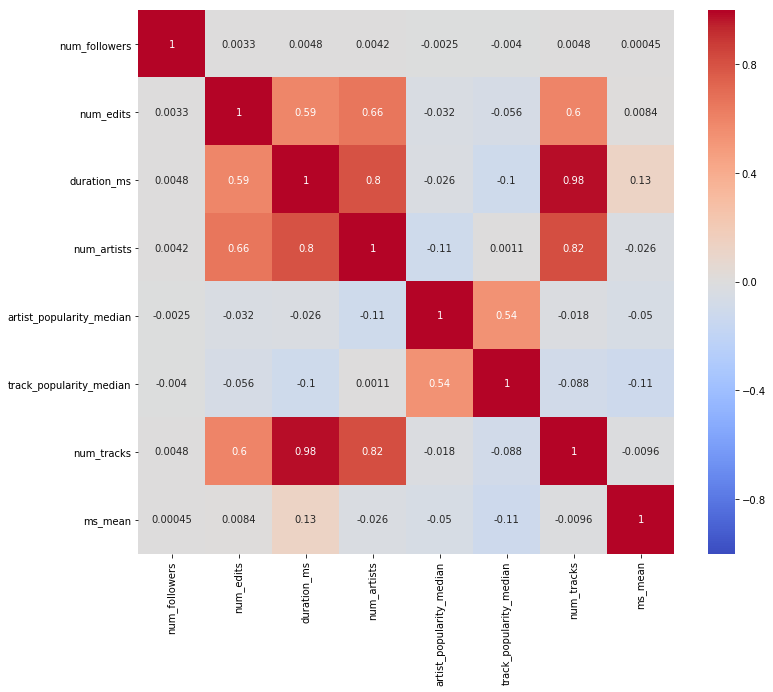

```python
fig, ax = plt.subplots(figsize=(12,10))
_ = sns.heatmap(playlist_df.drop(
    ['pid', 'collaborative', 'modified_at', 'artist_popularity',
     'track_popularity', 'num_albums', 'artist_popularity_mean',
     'track_popularity_mean'], axis=1).corr(),
                vmin=-1,
                vmax=1,
                ax=ax,
                cmap='coolwarm',
                annot=True)
```

Below is a summary of all notable correlations:

- Playlists that have more edits are longer, contain more artists and more tracks.
- Playlists that are longer have a higher amount of artists and tracks

All together not the most informative relations that can be derived from this data set.

# Summary

This fist analysis serves as a good starting point for further investigations and thoughts about sampling methods or important features to stratify on. We'll be using the insights gathered in this document to determine train, validation/development and testing sets.